# MNIST - Recognizing Digits

March 1, 2019

## Introduction

We are going to build three models to identify digits (0 to 9) from handwritten images.

1.kNN (Nearest Neighbor)  
2.SVM (Support Vector Machines)  
3.Random Forest

Our process will be as follows  
1. Load in our data do any pre-processing if necessary  
2. Build our models  
3. Evaluate performance through cross validation  
4. Apply them to our test dataset  
5. Submit to Kaggle

```r
EnsurePackage <- function(x) {
  x <- as.character(x)
  if (!require(x,character.only = T))
    install.packages(x,repos = "https://cran.cnr.berkeley.edu/")
  require(x,character.only = T)

}

EnsurePackage("caret") # set of functions that attempt to streamline the process for creating predictive models
EnsurePackage("randomForest") #Recursive Partitioning And Regression Trees
EnsurePackage("e1071") #Functions for latent class analysis, short time Fourier transform, fuzzy clustering, support vector machines, shortest path computation, bagged clustering, naive Bayes classifier
EnsurePackage("tidyverse") #Manipulating dataset
EnsurePackage("factoextra") #Visualization of PCA
```

## Exploratory Analysis and Preprocessing

Our exploratory analysis will be what was done in our previous assignment.For preprocessing we will try using PCA(principal component analysis) which can reduce the size of features to be used. This will improve our computation time and have minimal detrimental effect on the model accuracy.

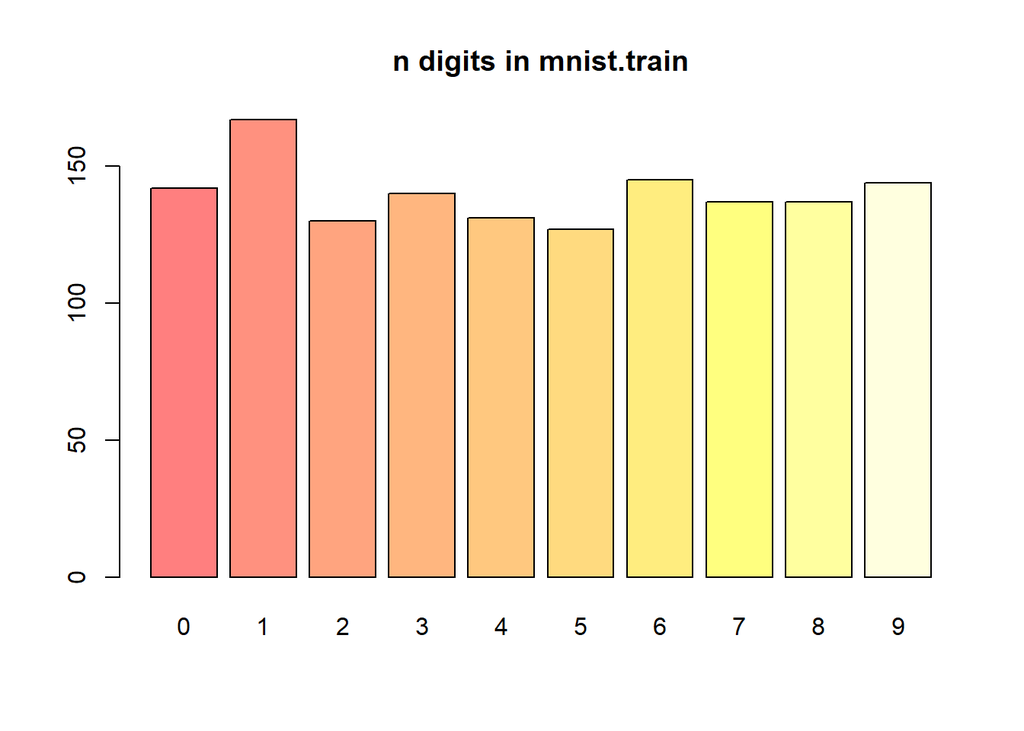

```r
#generate barplot to see data distribution
barplot(table(trn_sample[,1]), col=heat.colors(10, 0.5),
        main="n digits in mnist.train")
```

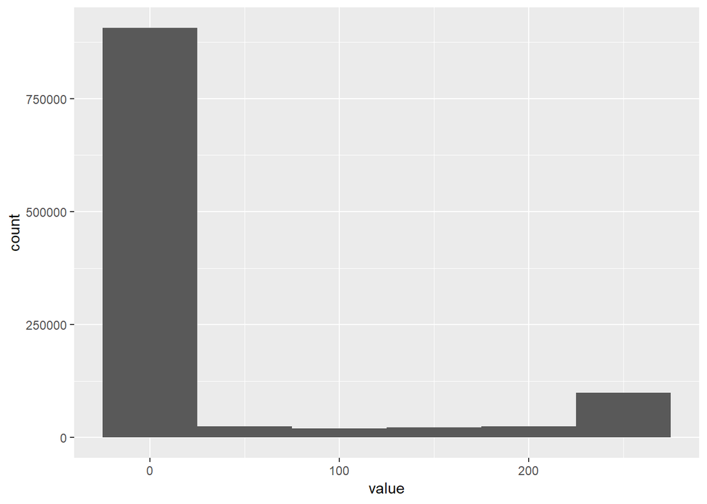

```r
#generate a plot to see value distribution in each cell
pixels_gathered <- gather(trn_sample,key = label)

ggplot(pixels_gathered, aes(value)) +
  geom_histogram(binwidth = 50)
```

PCA captures the variations present in the dataset by compressing original variables into small number of principal components that are capable of explaining most of the variance in data. This helps the model predict data without spending too much resources on learning lots of variables that have less or no impact on the target variable. We will first visualize how many variables are needed to capture the full data.

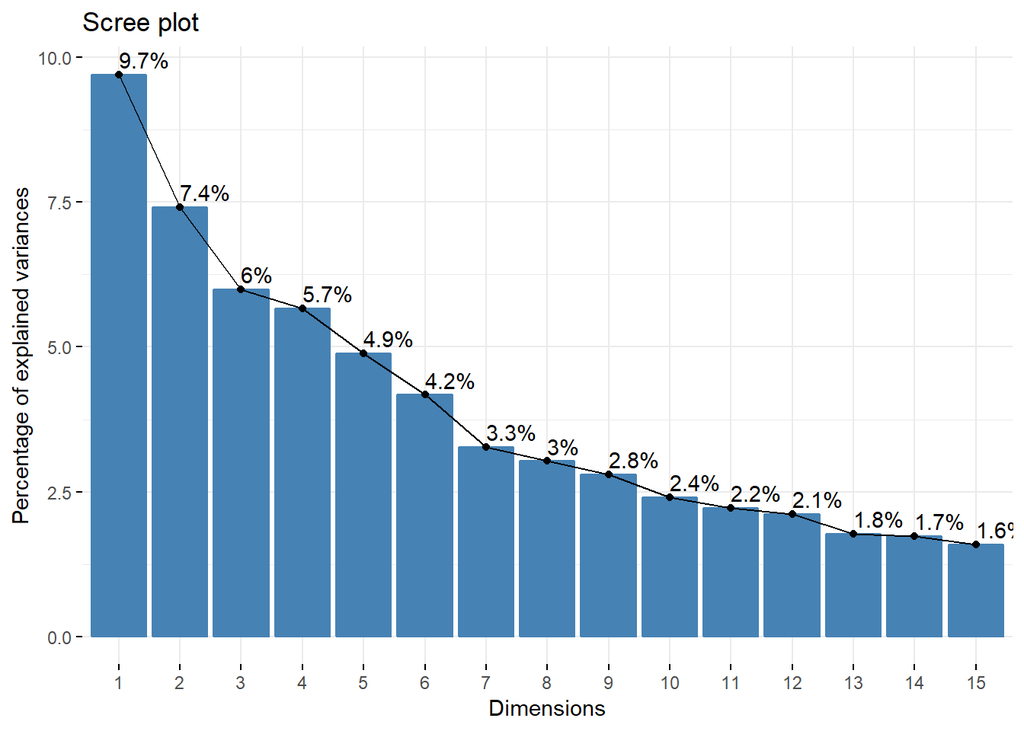

```r
full_pca = prcomp(trn_sample[,-1])

# Plot PCA components and the variation they cover
fviz_eig(full_pca,ncp = 15,addlabels = T)
```

```r
set.seed(8)
#Below function will remove zero variance, near zero variance variables and pca will find gather components that explain 98% variablility in dataset.
trn_processed <- preProcess(trn_sample,method = c("zv","nzv","pca"),thresh = 0.98)
trn_samplef <- predict(trn_processed,trn_sample)

trn_full_proc <- preProcess(mnst_train,method = c("zv","nzv","pca"),thresh = 0.98)
trn_full <- predict(trn_full_proc,mnst_train)

test_full_proc <- preProcess(mnst_test,method = c("zv","nzv"),thresh = 0.98)
test_full <- predict(trn_full_proc,mnst_test)

#Test data
```

After doing PCA, we are down to 149-150 components. These can capture 98 % of the variance in data. Lets train our models!

## KNN

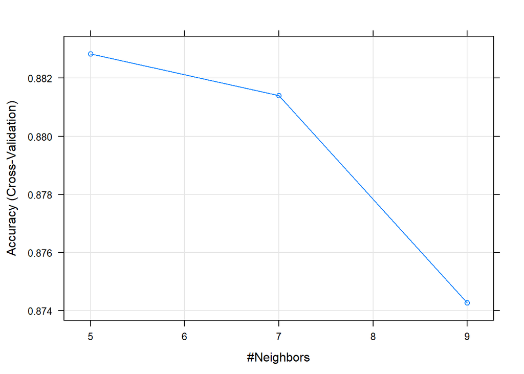

```r
set.seed(8)
#Knn with 3-fold cross validation
model_knn <-train(label ~ ., data = trn_samplef, method = "knn",
trControl = trainControl(method = "cv", number = 3))

plot(model_knn)
```

According to the plot, k=5 neighbours is the best option. After successful execution of the sample dataset, We will now train and test knn on the bigger dataset

```r
knn_model_f <- train(label ~ ., data = trn_full, method = "knn",
tuneGrid = data.frame(k = 5),
trControl = trainControl(method = "cv", number = 3))
```

```r
knn_pred <- predict(knn_model_f, newdata = test_full)

submission_knn <- data.frame(ImageId =1:nrow(test_full),
                            Label = knn_pred)
write.csv(submission_knn, file='submission_knn_hw7.csv', row.names=FALSE, quote=FALSE)
```

I submitted it on Kaggle and KNN achieved 96% accuracy.

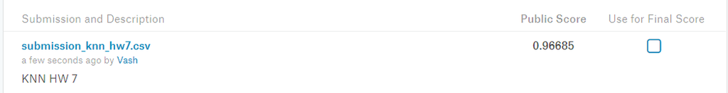

## Random Forest

Train the sample

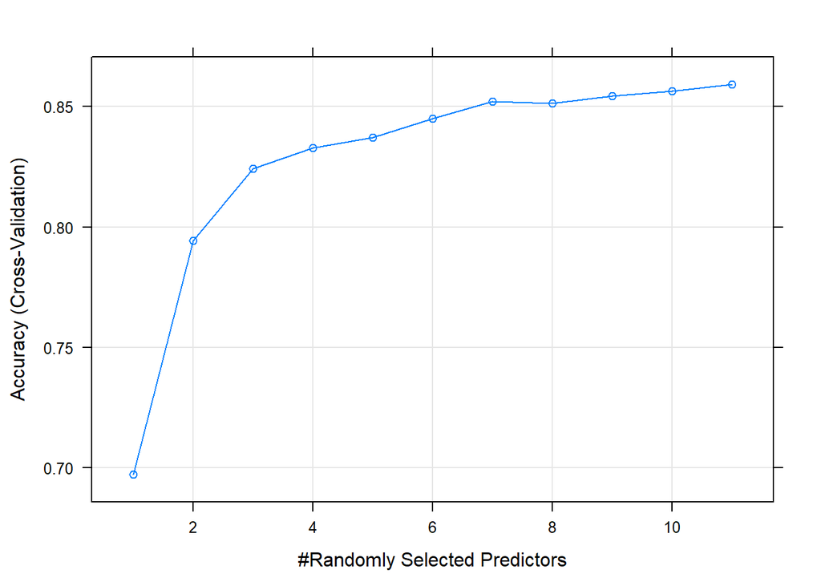

```r
model_rf <- train(label ~ ., data = trn_samplef, method = "rf",
tuneGrid = data.frame(mtry = seq(5:15)),
trControl = trainControl(method = "cv", number = 3))

plot(model_rf)
```

```r
set.seed(8)
model_rf_f <- train(label ~ ., data = trn_full, method = "rf",
tuneGrid = data.frame(mtry = 9),
trControl = trainControl(method = "cv", number = 3))
```

```r
rf_pred <- predict(model_rf_f, newdata = test_full)

submission_rf <- data.frame(ImageId =1:nrow(test_full),
                            Label = rf_pred)
write.csv(submission_rf, file='submission_rf_hw7.csv', row.names=FALSE, quote=FALSE)
```

Random forest gave us a prediction accuracy of 94% on Kaggle.

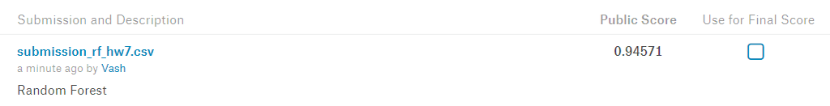

## SVM - Support Vector Machines

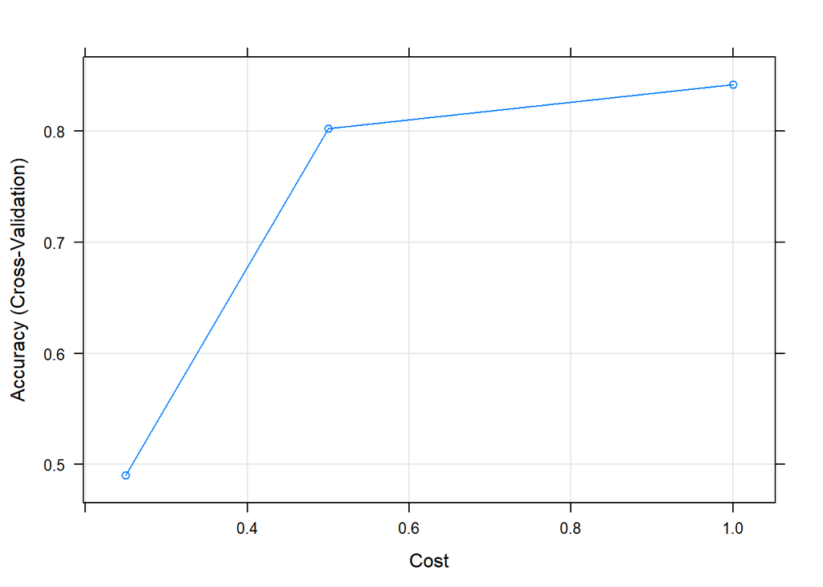

```r
#3 - fold cross validation
model_svm <- train(label ~ ., data = trn_samplef,
method = "svmRadial",trControl = trainControl(method = "cv", number = 3))

plot(model_svm)
```

According to the output the best value is for cost = 1. Applying the tuned model for the full train and test data

```r
model_svm_f <- train(label ~ ., data = trn_full,
method = "svmRadial",trControl = trainControl(method = "cv", number = 3),
tuneGrid = expand.grid(sigma=c(0.0034),C=c(1)))
```

```r
svm_pred <- predict(model_svm_f, newdata = test_full)

submission_rf <- data.frame(ImageId =1:nrow(test_full),
                            Label = svm_pred)
write.csv(submission_rf, file='submission_svm_hw7.csv', row.names=FALSE, quote=FALSE)
```

SVM gave us a prediction accuracy of 95% on Kaggle.

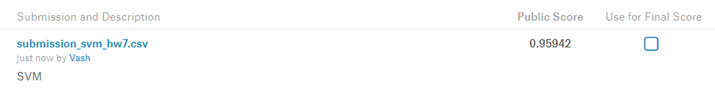

## Conclusion

The simplest model, the kNN Model, had a slight advantage over the SVM model. However this discrepancy can be attributed to random chance, and further tuning with either model can lead to a better result. In terms of computation speed however, kNN was by far the fastest in terms of computations. This make sense due it’s simplistic nature of calculating distance in Euclidean space. Since our data had some heavy preprocessing, it makes sense the kNN would do well with the training set. Also, kNN is a technique that is often used for image classification given that images have pixels values that have a definite range and therefore don’t really have outliers (especially when techniques like removing near zero variance predictors and PCA are applied).